# Neonatal Incubator Display Reader Model training and evaluation

This notebook demonstrates the complete **end-to-end workflow** for developing an automated system to detect and extract vital sign readings from neonatal incubator displays.

## Train detector model to locate vital sign regions

## 1: Run Overview

- Creates run directory under `artifacts/runs/<timestamp>`
- Uses YOLO-formatted data under `artifacts/yolo` (images + labels)
- Steps: data check → split + data.yaml → train with early stopping → eval + plots → qualitative preds → export weights → save config/metrics

```python
from pathlib import Path
import json, random, shutil, math
import numpy as np
import pandas as pd
import cv2
from ultralytics import YOLO
from datetime import datetime

# Reproducibility
SEED = 42
random.seed(SEED); np.random.seed(SEED)

# Paths
PROJECT_DIR = Path.cwd().parent
DATASET_DIR = PROJECT_DIR / "dataset"  # raw images (optional for viz)
YOLO_DATA_DIR = PROJECT_DIR  / "artifacts" / "yolo"  # expects images/ and labels/
RUN_TAG = "run_" + datetime.now().strftime('%Y%m%d_%H%M%S')
RUN_ROOT = PROJECT_DIR / "artifacts" / "runs" / RUN_TAG
SPLITS_DIR = RUN_ROOT / "splits"
MODEL_DIR = PROJECT_DIR / "models"
ARTIFACTS_DIR = PROJECT_DIR / "artifacts"
for d in [RUN_ROOT, SPLITS_DIR, MODEL_DIR, ARTIFACTS_DIR]:
    d.mkdir(parents=True, exist_ok=True)

CLASS_NAMES = [
    "air_temp_value",
    "heart_rate_value",
    "humidity_value",
    "skin_temp_value",
    "spo2_value",
]
CLASS_MAP = {name: idx for idx, name in enumerate(CLASS_NAMES)}
ID_TO_CLASS_NAME = {idx: name for name, idx in CLASS_MAP.items()}
CLASS_MAP
```

```
{'air_temp_value': 0,
 'heart_rate_value': 1,
 'humidity_value': 2,
 'skin_temp_value': 3,
 'spo2_value': 4}
```

## 2: Data Check

Discover raw images (for sanity plots). Training uses YOLO-formatted data in `artifacts/yolo` (images/labels).

```python
image_paths = []
for pattern in ("*.jpg","*.jpeg","*.png","*.JPG","*.JPEG","*.PNG"):
    image_paths.extend(DATASET_DIR.glob(pattern))
image_paths = sorted({p.resolve() for p in image_paths})
print(f"Found {len(image_paths)} raw images in {DATASET_DIR}")
```

```
Found 259 raw images in c:\Users\sahan\Desktop\MYProjects\PI_webUI_for_test-monitoring\lcd_ocr_readings\dataset
```

## 3: Quick Sample Visualization

Preview a few raw images; saves to the run folder.

[figure not shown]

```
Saved samples -> c:\Users\sahan\Desktop\MYProjects\PI_webUI_for_test-monitoring\lcd_ocr_readings\artifacts\runs\run_20251203_134740\samples.png
```

```python
import matplotlib.pyplot as plt

SAMPLES_PNG = RUN_ROOT / "samples.png"

def plot_samples(paths, n=6, cols=3):
    if not paths:
        print("No raw images to plot.")
        return
    sample = random.sample(paths, min(n, len(paths)))
    rows = int(np.ceil(len(sample)/cols))
    plt.figure(figsize=(4*cols, 3*rows))
    for i,p in enumerate(sample,1):
        img = cv2.cvtColor(cv2.imread(str(p)), cv2.COLOR_BGR2RGB)
        plt.subplot(rows, cols, i)
        plt.imshow(img); plt.title(p.name); plt.axis("off")
    plt.tight_layout()
    plt.savefig(SAMPLES_PNG, dpi=150, bbox_inches='tight')
    plt.show()
    print(f"Saved samples -> {SAMPLES_PNG}")

plot_samples(image_paths, n=6, cols=3)
```

## 4: Annotation Workflow with Label Studio

**Objective:** Create bounding box annotations for each vital sign region in the incubator display.

**Tool:** Label Studio - an open-source data labeling platform

**Setup Instructions:**

1. Install Label Studio (one-time setup):

   ```
   pip install label-studio
   label-studio start --port 8080
   ```

2. Create a new project named "Incubator Display Detection"
3. Import images from the `dataset/` directory
4. Configure the labeling interface with **bounding box** tool for the following classes:
   - air_temp_value
   - heart_rate_value
   - humidity_value
   - skin_temp_value
   - spo2_value
5. Annotate all images
6. Export annotations in **YOLO format**

[figure not shown]

## 5: Split YOLO Data & Write data.yaml

Uses existing YOLO-format data in `artifacts/yolo/images` and `artifacts/yolo/labels`. Creates train/val/test splits under the run directory and writes `data.yaml` there.

```python
import yaml
from pathlib import Path

def normalize_labels(images_dir: Path, labels_dir: Path, out_dir: Path) -> int:
    """
    Copy labels into out_dir renamed to match image basenames, allowing prefixed label stems.
    Returns count of matched pairs.
    """
    out_dir.mkdir(parents=True, exist_ok=True)
    labels = list(labels_dir.glob("*.txt"))

    def find_label_for_image(img_stem: str):
        for lbl in labels:
            if lbl.stem.endswith(img_stem):
                return lbl
        return None

    copied, missing = 0, []
    for img in images_dir.glob("*"):
        if img.suffix.lower() not in {".jpg", ".jpeg", ".png", ".bmp"}:
            continue
        match = find_label_for_image(img.stem)
        if match:
            shutil.copy2(match, out_dir / f"{img.stem}.txt")
            copied += 1
        else:
            missing.append(img.name)
    if missing:
        print(f"Missing labels for {len(missing)} images (showing up to 10): {missing[:10]}")
    print(f"Normalized labels copied: {copied} -> {out_dir}")
    return copied

def split_dataset(yolo_dir, train=0.7, val=0.2, test=0.1, seed=SEED):
    assert math.isclose(train+val+test, 1.0, rel_tol=1e-6)
    yolo_dir = Path(yolo_dir)
    images_dir = yolo_dir / "images"
    raw_labels_dir = yolo_dir / "labels"
    norm_labels_dir = yolo_dir / "labels_normalized"

    if not images_dir.exists() or not raw_labels_dir.exists():
        raise FileNotFoundError(f"YOLO images/labels missing under {yolo_dir}")

    # Normalize labels to match image basenames
    normalize_labels(images_dir, raw_labels_dir, norm_labels_dir)

    imgs = []
    for ext in (".jpg", ".jpeg", ".png", ".bmp", ".JPG", ".JPEG", ".PNG"):
        imgs.extend(images_dir.glob(f"*{ext}"))
    if not imgs:
        raise FileNotFoundError(f"No images in {images_dir}")

    pairs, missing = [], []
    for img in sorted(imgs):
        label = norm_labels_dir / f"{img.stem}.txt"
        if not label.exists():
            missing.append(img.name)
            continue
        pairs.append((img, label))
    if missing:
        print(f"Skipping {len(missing)} images without labels after normalization")
    if not pairs:
        raise FileNotFoundError("No image/label pairs found")

    rng = random.Random(seed); rng.shuffle(pairs)
    n = len(pairs); tc = int(n * train); vc = tc + int(n * val)
    splits = {"train": pairs[:tc], "val": pairs[tc:vc], "test": pairs[vc:]}

    split_root = Path(SPLITS_DIR)
    for split, items in splits.items():
        img_out, lbl_out = split_root / split / "images", split_root / split / "labels"
        img_out.mkdir(parents=True, exist_ok=True); lbl_out.mkdir(parents=True, exist_ok=True)
        for img, lbl in items:
            shutil.copy2(img, img_out / img.name)
            shutil.copy2(lbl, lbl_out / lbl.name)
    print({k: len(v) for k, v in splits.items()})
    return split_root

def write_data_yaml(split_root, class_names, filename="data.yaml"):
    data = {
        "path": str(split_root),
        "train": "train/images",
        "val": "val/images",
        "test": "test/images",
        "nc": len(class_names),
        "names": class_names
    }
    path = split_root / filename
    with open(path, "w") as f:
        yaml.dump(data, f, default_flow_style=False)
    return path

split_root = split_dataset(YOLO_DATA_DIR)
data_yaml_path = write_data_yaml(split_root, CLASS_NAMES)
print(f"data.yaml -> {data_yaml_path}")
```

[output not shown]

## 6: Train YOLOv8 detector model with Early Stopping

- Max epochs: 100
- Early stop patience: 10 (stop when val stops improving)
- Seeds set for reproducibility Artifacts stay under this run folder; prior runs remain intact.

```python
import torch
from torch.serialization import add_safe_globals
from ultralytics.nn.tasks import DetectionModel
from ultralytics.nn import modules as yolo_modules
from torch.nn import modules as torch_nn_modules

# Allowlist Ultralytics/Torch classes for torch.load
add_safe_globals(
    [DetectionModel]
    + [obj for obj in vars(yolo_modules).values() if isinstance(obj, type)]
    + [obj for obj in vars(torch_nn_modules).values() if isinstance(obj, type)]
)

# Backward-compatible torch.load
if not hasattr(torch, "_orig_load"):
    torch._orig_load = torch.load

def _compat_load(*args, **kwargs):
    kwargs.setdefault("weights_only", False)
    return torch._orig_load(*args, **kwargs)

torch.load = _compat_load


def train_detector(data_yaml, epochs=100, imgsz=640, batch=16, model="yolov8n.pt",
                   project=RUN_ROOT/"train", name="exp", patience=10):
    model = YOLO(model)
    results = model.train(
        data=str(data_yaml),
        epochs=epochs,
        imgsz=imgsz,
        batch=batch,
        patience=patience,
        seed=SEED,
        project=str(project),
        name=name,
        exist_ok=True,
    )
    return model, results

print(f"Run directory: {RUN_ROOT}")
detector, train_results = train_detector(data_yaml_path)
```

[output not shown]

```
train: New cache created: C:\Users\sahan\Desktop\MYProjects\PI_webUI_for_test-monitoring\lcd_ocr_readings\artifacts\runs\run_20251203_134740\splits\train\labels.cache
```

```
albumentations: Blur(p=0.01, blur_limit=(3, 7)), MedianBlur(p=0.01, blur_limit=(3, 7)), ToGray(p=0.01), CLAHE(p=0.01, clip_limit=(1, 4.0), tile_grid_size=(8, 8))
```

```
val: New cache created: C:\Users\sahan\Desktop\MYProjects\PI_webUI_for_test-monitoring\lcd_ocr_readings\artifacts\runs\run_20251203_134740\splits\val\labels.cache
```

```
Plotting labels to c:\Users\sahan\Desktop\MYProjects\PI_webUI_for_test-monitoring\lcd_ocr_readings\artifacts\runs\run_20251203_134740\train\exp\labels.jpg...
optimizer: 'optimizer=auto' found, ignoring 'lr0=0.01' and 'momentum=0.937' and determining best 'optimizer', 'lr0' and 'momentum' automatically...
optimizer: AdamW(lr=0.001111, momentum=0.9) with parameter groups 57 weight(decay=0.0), 64 weight(decay=0.0005), 63 bias(decay=0.0)
```

[output not shown]

```
MLflow: logging run_id(4ac459be6656458b98611c3fb71468a7) to runs\mlflow
MLflow: view at http://127.0.0.1:5000 with 'mlflow server --backend-store-uri runs\mlflow'
MLflow: disable with 'yolo settings mlflow=False'
100 epochs...

      Epoch    GPU_mem   box_loss   cls_loss   dfl_loss  Instances       Size
```

```
      1/100         0G      2.077      4.078      1.511         22        640: 100%|██████████| 16/16 [01:40<00:00,  6.27s/it]
                 Class     Images  Instances      Box(P          R      mAP50  mAP50-95): 100%|██████████| 3/3 [00:11<00:00,  3.99s/it]
```

```
                   all         96        480     0.0077      0.295      0.189      0.131
```

```
      Epoch    GPU_mem   box_loss   cls_loss   dfl_loss  Instances       Size
```

```
      2/100         0G      1.472      2.277      1.118         11        640: 100%|██████████| 16/16 [01:34<00:00,  5.93s/it]
                 Class     Images  Instances      Box(P          R      mAP50  mAP50-95): 100%|██████████| 3/3 [00:11<00:00,  3.85s/it]
```

```
                   all         96        480          1     0.0709      0.358       0.24
```

```
      Epoch    GPU_mem   box_loss   cls_loss   dfl_loss  Instances       Size
```

```
      3/100         0G      1.293      1.307      1.023         19        640: 100%|██████████| 16/16 [01:32<00:00,  5.78s/it]
                 Class     Images  Instances      Box(P          R      mAP50  mAP50-95): 100%|██████████| 3/3 [00:13<00:00,  4.36s/it]
```

```
                   all         96        480     0.0215      0.909      0.809      0.513
```

```
      Epoch    GPU_mem   box_loss   cls_loss   dfl_loss  Instances       Size
```

```
      4/100         0G      1.198      1.083     0.9938         14        640: 100%|██████████| 16/16 [01:29<00:00,  5.60s/it]
                 Class     Images  Instances      Box(P          R      mAP50  mAP50-95): 100%|██████████| 3/3 [00:11<00:00,  3.80s/it]
```

```
                   all         96        480      0.997      0.234      0.954      0.653
```

```
      Epoch    GPU_mem   box_loss   cls_loss   dfl_loss  Instances       Size
```

```
      5/100         0G      1.117     0.9536     0.9735         19        640: 100%|██████████| 16/16 [01:31<00:00,  5.73s/it]
                 Class     Images  Instances      Box(P          R      mAP50  mAP50-95): 100%|██████████| 3/3 [00:11<00:00,  3.83s/it]
```

```
                   all         96        480      0.998      0.421      0.952      0.656
```

```
      Epoch    GPU_mem   box_loss   cls_loss   dfl_loss  Instances       Size
```

```
      6/100         0G      1.123     0.9275     0.9839          7        640: 100%|██████████| 16/16 [01:32<00:00,  5.76s/it]
                 Class     Images  Instances      Box(P          R      mAP50  mAP50-95): 100%|██████████| 3/3 [00:11<00:00,  3.99s/it]
```

```
                   all         96        480      0.943      0.625      0.976      0.665
```

```
      Epoch    GPU_mem   box_loss   cls_loss   dfl_loss  Instances       Size
```

```
      7/100         0G      1.113     0.8905      0.968          7        640: 100%|██████████| 16/16 [01:28<00:00,  5.51s/it]
                 Class     Images  Instances      Box(P          R      mAP50  mAP50-95): 100%|██████████| 3/3 [00:13<00:00,  4.38s/it]
```

```
                   all         96        480      0.979      0.949      0.983      0.685
```

```
      Epoch    GPU_mem   box_loss   cls_loss   dfl_loss  Instances       Size
```

```
      8/100         0G      1.078     0.8397     0.9555         22        640: 100%|██████████| 16/16 [01:28<00:00,  5.54s/it]
                 Class     Images  Instances      Box(P          R      mAP50  mAP50-95): 100%|██████████| 3/3 [00:12<00:00,  4.02s/it]
```

```
                   all         96        480       0.99       0.97      0.984       0.68
```

```
      Epoch    GPU_mem   box_loss   cls_loss   dfl_loss  Instances       Size
```

```
      9/100         0G      1.066     0.8109     0.9839         10        640: 100%|██████████| 16/16 [01:31<00:00,  5.73s/it]
                 Class     Images  Instances      Box(P          R      mAP50  mAP50-95): 100%|██████████| 3/3 [00:12<00:00,  4.08s/it]
```

```
                   all         96        480      0.992      0.976      0.984      0.676
```

```
      Epoch    GPU_mem   box_loss   cls_loss   dfl_loss  Instances       Size
```

```
     10/100         0G      1.055     0.7637     0.9555         10        640: 100%|██████████| 16/16 [01:29<00:00,  5.57s/it]
                 Class     Images  Instances      Box(P          R      mAP50  mAP50-95): 100%|██████████| 3/3 [00:13<00:00,  4.55s/it]
```

```
                   all         96        480      0.991      0.985      0.984      0.669
```

```
      Epoch    GPU_mem   box_loss   cls_loss   dfl_loss  Instances       Size
```

```
     11/100         0G      1.117     0.7615     0.9746         30        640: 100%|██████████| 16/16 [01:37<00:00,  6.09s/it]
                 Class     Images  Instances      Box(P          R      mAP50  mAP50-95): 100%|██████████| 3/3 [00:13<00:00,  4.43s/it]
```

```
                   all         96        480      0.988      0.988      0.986       0.67
```

```
      Epoch    GPU_mem   box_loss   cls_loss   dfl_loss  Instances       Size
```

```
     12/100         0G      1.112     0.7673     0.9771         17        640: 100%|██████████| 16/16 [01:39<00:00,  6.20s/it]
                 Class     Images  Instances      Box(P          R      mAP50  mAP50-95): 100%|██████████| 3/3 [00:12<00:00,  4.33s/it]
```

```
                   all         96        480      0.986      0.989      0.986      0.694
```

```
      Epoch    GPU_mem   box_loss   cls_loss   dfl_loss  Instances       Size
```

```
     13/100         0G      1.078     0.7343     0.9549         16        640: 100%|██████████| 16/16 [01:32<00:00,  5.81s/it]
                 Class     Images  Instances      Box(P          R      mAP50  mAP50-95): 100%|██████████| 3/3 [00:11<00:00,  3.87s/it]
```

```
                   all         96        480      0.992      0.984      0.988      0.697
```

```
      Epoch    GPU_mem   box_loss   cls_loss   dfl_loss  Instances       Size
```

```
     14/100         0G       1.06     0.7393     0.9714         30        640: 100%|██████████| 16/16 [01:37<00:00,  6.09s/it]
                 Class     Images  Instances      Box(P          R      mAP50  mAP50-95): 100%|██████████| 3/3 [00:11<00:00,  3.83s/it]
```

```
                   all         96        480      0.991      0.986      0.988      0.691
```

```
      Epoch    GPU_mem   box_loss   cls_loss   dfl_loss  Instances       Size
```

```
     15/100         0G      1.015     0.6773     0.9431         19        640: 100%|██████████| 16/16 [01:28<00:00,  5.51s/it]
                 Class     Images  Instances      Box(P          R      mAP50  mAP50-95): 100%|██████████| 3/3 [00:12<00:00,  4.19s/it]
```

```
                   all         96        480      0.994      0.988      0.989      0.707
```

```
      Epoch    GPU_mem   box_loss   cls_loss   dfl_loss  Instances       Size
```

```
     16/100         0G      1.042     0.6838     0.9485         23        640: 100%|██████████| 16/16 [01:28<00:00,  5.52s/it]
                 Class     Images  Instances      Box(P          R      mAP50  mAP50-95): 100%|██████████| 3/3 [00:11<00:00,  3.72s/it]
```

```
                   all         96        480      0.994      0.988       0.99      0.704
```

```
      Epoch    GPU_mem   box_loss   cls_loss   dfl_loss  Instances       Size
```

```
     17/100         0G      1.034     0.6541     0.9507         19        640: 100%|██████████| 16/16 [01:29<00:00,  5.60s/it]
                 Class     Images  Instances      Box(P          R      mAP50  mAP50-95): 100%|██████████| 3/3 [00:11<00:00,  3.80s/it]
```

```
                   all         96        480      0.993      0.988       0.99       0.69
```

```
      Epoch    GPU_mem   box_loss   cls_loss   dfl_loss  Instances       Size
```

```
     18/100         0G      1.044     0.6632     0.9653          8        640: 100%|██████████| 16/16 [01:28<00:00,  5.54s/it]
                 Class     Images  Instances      Box(P          R      mAP50  mAP50-95): 100%|██████████| 3/3 [00:12<00:00,  4.29s/it]
```

```
                   all         96        480      0.989      0.986      0.989      0.708
```

```
      Epoch    GPU_mem   box_loss   cls_loss   dfl_loss  Instances       Size
```

```
     19/100         0G      1.024      0.641     0.9593          9        640: 100%|██████████| 16/16 [01:29<00:00,  5.57s/it]
                 Class     Images  Instances      Box(P          R      mAP50  mAP50-95): 100%|██████████| 3/3 [00:11<00:00,  3.73s/it]
```

```
                   all         96        480      0.995      0.987      0.988        0.7
```

```
      Epoch    GPU_mem   box_loss   cls_loss   dfl_loss  Instances       Size
```

```
     20/100         0G      1.034     0.6363      0.939         19        640: 100%|██████████| 16/16 [01:30<00:00,  5.68s/it]
                 Class     Images  Instances      Box(P          R      mAP50  mAP50-95): 100%|██████████| 3/3 [00:11<00:00,  3.71s/it]
```

```
                   all         96        480      0.996      0.987      0.987      0.702
```

```
      Epoch    GPU_mem   box_loss   cls_loss   dfl_loss  Instances       Size
```

```
     21/100         0G      1.045     0.6333     0.9594         22        640: 100%|██████████| 16/16 [01:30<00:00,  5.66s/it]
                 Class     Images  Instances      Box(P          R      mAP50  mAP50-95): 100%|██████████| 3/3 [00:13<00:00,  4.36s/it]
```

```
                   all         96        480      0.992       0.99      0.991      0.713
```

```
      Epoch    GPU_mem   box_loss   cls_loss   dfl_loss  Instances       Size
```

```
     22/100         0G     0.9986     0.6141     0.9459         22        640: 100%|██████████| 16/16 [01:28<00:00,  5.55s/it]
                 Class     Images  Instances      Box(P          R      mAP50  mAP50-95): 100%|██████████| 3/3 [00:11<00:00,  3.73s/it]
```

```
                   all         96        480      0.996      0.987      0.992      0.707
```

```
      Epoch    GPU_mem   box_loss   cls_loss   dfl_loss  Instances       Size
```

```
     23/100         0G      1.012      0.598     0.9364         17        640: 100%|██████████| 16/16 [01:33<00:00,  5.83s/it]
                 Class     Images  Instances      Box(P          R      mAP50  mAP50-95): 100%|██████████| 3/3 [00:10<00:00,  3.63s/it]
```

```
                   all         96        480      0.988      0.988      0.991      0.716
```

```
      Epoch    GPU_mem   box_loss   cls_loss   dfl_loss  Instances       Size
```

```
     24/100         0G       1.02     0.5987     0.9414         11        640: 100%|██████████| 16/16 [01:29<00:00,  5.57s/it]
                 Class     Images  Instances      Box(P          R      mAP50  mAP50-95): 100%|██████████| 3/3 [00:12<00:00,  4.20s/it]
```

```
                   all         96        480      0.994      0.987       0.99      0.711
```

```
      Epoch    GPU_mem   box_loss   cls_loss   dfl_loss  Instances       Size
```

```
     25/100         0G       1.02     0.5791     0.9608         20        640: 100%|██████████| 16/16 [01:31<00:00,  5.74s/it]
                 Class     Images  Instances      Box(P          R      mAP50  mAP50-95): 100%|██████████| 3/3 [00:12<00:00,  4.05s/it]
```

```
                   all         96        480      0.995      0.988      0.991      0.719
```

```
      Epoch    GPU_mem   box_loss   cls_loss   dfl_loss  Instances       Size
```

```
     26/100         0G       1.01     0.5877      0.957         11        640: 100%|██████████| 16/16 [01:30<00:00,  5.65s/it]
                 Class     Images  Instances      Box(P          R      mAP50  mAP50-95): 100%|██████████| 3/3 [00:11<00:00,  3.68s/it]
```

```
                   all         96        480      0.995      0.988      0.991      0.715
```

```
      Epoch    GPU_mem   box_loss   cls_loss   dfl_loss  Instances       Size
```

```
     27/100         0G      1.017     0.5669     0.9454         20        640: 100%|██████████| 16/16 [01:27<00:00,  5.44s/it]
                 Class     Images  Instances      Box(P          R      mAP50  mAP50-95): 100%|██████████| 3/3 [00:12<00:00,  4.14s/it]
```

```
                   all         96        480      0.996       0.99      0.992      0.725
```

```
      Epoch    GPU_mem   box_loss   cls_loss   dfl_loss  Instances       Size
```

```
     28/100         0G      1.008     0.5795     0.9471          4        640: 100%|██████████| 16/16 [01:29<00:00,  5.62s/it]
                 Class     Images  Instances      Box(P          R      mAP50  mAP50-95): 100%|██████████| 3/3 [00:12<00:00,  4.33s/it]
```

```
                   all         96        480      0.996      0.989      0.991      0.716
```

```
      Epoch    GPU_mem   box_loss   cls_loss   dfl_loss  Instances       Size
```

```
     29/100         0G      1.013     0.5633     0.9449         13        640: 100%|██████████| 16/16 [01:38<00:00,  6.15s/it]
                 Class     Images  Instances      Box(P          R      mAP50  mAP50-95): 100%|██████████| 3/3 [00:12<00:00,  4.02s/it]
```

```
                   all         96        480      0.991      0.993      0.992      0.722
```

```
      Epoch    GPU_mem   box_loss   cls_loss   dfl_loss  Instances       Size
```

```
     30/100         0G     0.9918     0.5606     0.9521         15        640: 100%|██████████| 16/16 [01:32<00:00,  5.78s/it]
                 Class     Images  Instances      Box(P          R      mAP50  mAP50-95): 100%|██████████| 3/3 [00:10<00:00,  3.55s/it]
```

```
                   all         96        480      0.996      0.991      0.992      0.711
```

```
      Epoch    GPU_mem   box_loss   cls_loss   dfl_loss  Instances       Size
```

```
     31/100         0G     0.9861     0.5551     0.9414         22        640: 100%|██████████| 16/16 [01:26<00:00,  5.39s/it]
                 Class     Images  Instances      Box(P          R      mAP50  mAP50-95): 100%|██████████| 3/3 [00:11<00:00,  3.70s/it]
```

```
                   all         96        480      0.994      0.991      0.991      0.714
```

```
      Epoch    GPU_mem   box_loss   cls_loss   dfl_loss  Instances       Size
```

```
     32/100         0G     0.9917     0.5493     0.9341         29        640: 100%|██████████| 16/16 [01:25<00:00,  5.34s/it]
                 Class     Images  Instances      Box(P          R      mAP50  mAP50-95): 100%|██████████| 3/3 [00:10<00:00,  3.59s/it]
```

```
                   all         96        480      0.991       0.99      0.992        0.7
```

```
      Epoch    GPU_mem   box_loss   cls_loss   dfl_loss  Instances       Size
```

```
     33/100         0G      0.996     0.5451     0.9424         24        640: 100%|██████████| 16/16 [01:28<00:00,  5.50s/it]
                 Class     Images  Instances      Box(P          R      mAP50  mAP50-95): 100%|██████████| 3/3 [00:10<00:00,  3.62s/it]
```

```
                   all         96        480       0.99      0.988      0.992      0.706
```

```
      Epoch    GPU_mem   box_loss   cls_loss   dfl_loss  Instances       Size
```

```
     34/100         0G     0.9882     0.5551     0.9321         13        640: 100%|██████████| 16/16 [01:25<00:00,  5.36s/it]
                 Class     Images  Instances      Box(P          R      mAP50  mAP50-95): 100%|██████████| 3/3 [00:12<00:00,  4.04s/it]
```

```
                   all         96        480      0.995      0.985       0.99      0.713
```

```
      Epoch    GPU_mem   box_loss   cls_loss   dfl_loss  Instances       Size
```

```
     35/100         0G     0.9905     0.5391     0.9279         19        640: 100%|██████████| 16/16 [01:25<00:00,  5.36s/it]
                 Class     Images  Instances      Box(P          R      mAP50  mAP50-95): 100%|██████████| 3/3 [00:10<00:00,  3.52s/it]
```

```
                   all         96        480      0.996      0.987      0.991      0.729
```

```
      Epoch    GPU_mem   box_loss   cls_loss   dfl_loss  Instances       Size
```

```
     36/100         0G      1.013     0.5428      0.952         20        640: 100%|██████████| 16/16 [01:28<00:00,  5.52s/it]
                 Class     Images  Instances      Box(P          R      mAP50  mAP50-95): 100%|██████████| 3/3 [00:10<00:00,  3.60s/it]
```

```
                   all         96        480      0.996      0.989      0.989      0.715
```

```
      Epoch    GPU_mem   box_loss   cls_loss   dfl_loss  Instances       Size
```

```
     37/100         0G     0.9982     0.5409      0.941         23        640: 100%|██████████| 16/16 [01:25<00:00,  5.34s/it]
                 Class     Images  Instances      Box(P          R      mAP50  mAP50-95): 100%|██████████| 3/3 [00:11<00:00,  3.86s/it]
```

```
                   all         96        480      0.992      0.991       0.99      0.718
```

```
      Epoch    GPU_mem   box_loss   cls_loss   dfl_loss  Instances       Size
```

```
     38/100         0G      1.011     0.5258     0.9421         22        640: 100%|██████████| 16/16 [01:27<00:00,  5.45s/it]
                 Class     Images  Instances      Box(P          R      mAP50  mAP50-95): 100%|██████████| 3/3 [00:10<00:00,  3.64s/it]
```

```
                   all         96        480      0.996      0.991      0.991      0.721
```

```
      Epoch    GPU_mem   box_loss   cls_loss   dfl_loss  Instances       Size
```

```
     39/100         0G     0.9962     0.5244     0.9401         28        640: 100%|██████████| 16/16 [01:28<00:00,  5.51s/it]
                 Class     Images  Instances      Box(P          R      mAP50  mAP50-95): 100%|██████████| 3/3 [00:11<00:00,  3.74s/it]
```

```
                   all         96        480      0.994      0.992      0.989      0.724
```

```
      Epoch    GPU_mem   box_loss   cls_loss   dfl_loss  Instances       Size
```

```
     40/100         0G     0.9776     0.5274     0.9292         13        640: 100%|██████████| 16/16 [01:29<00:00,  5.59s/it]
                 Class     Images  Instances      Box(P          R      mAP50  mAP50-95): 100%|██████████| 3/3 [00:11<00:00,  3.97s/it]
```

```
                   all         96        480      0.996       0.99      0.991      0.731
```

```
      Epoch    GPU_mem   box_loss   cls_loss   dfl_loss  Instances       Size
```

```
     41/100         0G     0.9785     0.5234     0.9382         10        640: 100%|██████████| 16/16 [01:32<00:00,  5.76s/it]
                 Class     Images  Instances      Box(P          R      mAP50  mAP50-95): 100%|██████████| 3/3 [00:12<00:00,  4.06s/it]
```

```
                   all         96        480      0.997      0.992       0.99       0.72
```

```
      Epoch    GPU_mem   box_loss   cls_loss   dfl_loss  Instances       Size
```

```
     42/100         0G     0.9854     0.5155     0.9274         25        640: 100%|██████████| 16/16 [01:32<00:00,  5.79s/it]
                 Class     Images  Instances      Box(P          R      mAP50  mAP50-95): 100%|██████████| 3/3 [00:10<00:00,  3.54s/it]
```

```
                   all         96        480      0.992       0.99       0.99       0.73
```

```
      Epoch    GPU_mem   box_loss   cls_loss   dfl_loss  Instances       Size
```

```
     43/100         0G      0.963     0.5047     0.9192         14        640: 100%|██████████| 16/16 [01:23<00:00,  5.24s/it]
                 Class     Images  Instances      Box(P          R      mAP50  mAP50-95): 100%|██████████| 3/3 [00:11<00:00,  3.90s/it]
```

```
                   all         96        480       0.99      0.991       0.99       0.73
```

```
      Epoch    GPU_mem   box_loss   cls_loss   dfl_loss  Instances       Size
```

```
     44/100         0G     0.9607     0.5004     0.9277         17        640: 100%|██████████| 16/16 [01:24<00:00,  5.26s/it]
                 Class     Images  Instances      Box(P          R      mAP50  mAP50-95): 100%|██████████| 3/3 [00:10<00:00,  3.54s/it]
```

```
                   all         96        480      0.991      0.991      0.992      0.731
```

```
      Epoch    GPU_mem   box_loss   cls_loss   dfl_loss  Instances       Size
```

```
     45/100         0G      0.962      0.499     0.9328          7        640: 100%|██████████| 16/16 [01:28<00:00,  5.51s/it]
                 Class     Images  Instances      Box(P          R      mAP50  mAP50-95): 100%|██████████| 3/3 [00:12<00:00,  4.16s/it]
```

```
                   all         96        480      0.992      0.991      0.988      0.722
```

```
      Epoch    GPU_mem   box_loss   cls_loss   dfl_loss  Instances       Size
```

```
     46/100         0G     0.9741     0.5027     0.9261         15        640: 100%|██████████| 16/16 [01:32<00:00,  5.77s/it]
                 Class     Images  Instances      Box(P          R      mAP50  mAP50-95): 100%|██████████| 3/3 [00:12<00:00,  4.12s/it]
```

```
                   all         96        480      0.992      0.988      0.989      0.727
```

```
      Epoch    GPU_mem   box_loss   cls_loss   dfl_loss  Instances       Size
```

```
     47/100         0G      0.961      0.493     0.9365          9        640: 100%|██████████| 16/16 [01:31<00:00,  5.72s/it]
                 Class     Images  Instances      Box(P          R      mAP50  mAP50-95): 100%|██████████| 3/3 [00:10<00:00,  3.50s/it]
```

```
                   all         96        480      0.995       0.99      0.989      0.726
```

```
      Epoch    GPU_mem   box_loss   cls_loss   dfl_loss  Instances       Size
```

```
     48/100         0G     0.9697     0.5121     0.9271         12        640: 100%|██████████| 16/16 [01:31<00:00,  5.74s/it]
                 Class     Images  Instances      Box(P          R      mAP50  mAP50-95): 100%|██████████| 3/3 [00:11<00:00,  3.82s/it]
```

```
                   all         96        480      0.994      0.991      0.991      0.731
```

```
      Epoch    GPU_mem   box_loss   cls_loss   dfl_loss  Instances       Size
```

```
     49/100         0G     0.9715     0.5064     0.9325          5        640: 100%|██████████| 16/16 [01:27<00:00,  5.49s/it]
                 Class     Images  Instances      Box(P          R      mAP50  mAP50-95): 100%|██████████| 3/3 [00:18<00:00,  6.11s/it]
```

```
                   all         96        480      0.993      0.994      0.991      0.737
```

```
      Epoch    GPU_mem   box_loss   cls_loss   dfl_loss  Instances       Size
```

```
     50/100         0G       0.96     0.4821     0.9319         10        640: 100%|██████████| 16/16 [01:54<00:00,  7.16s/it]
                 Class     Images  Instances      Box(P          R      mAP50  mAP50-95): 100%|██████████| 3/3 [00:15<00:00,  5.11s/it]
```

```
                   all         96        480      0.993      0.994      0.991      0.733
```

```
      Epoch    GPU_mem   box_loss   cls_loss   dfl_loss  Instances       Size
```

```
     51/100         0G     0.9607     0.5002     0.9297         19        640: 100%|██████████| 16/16 [02:00<00:00,  7.50s/it]
                 Class     Images  Instances      Box(P          R      mAP50  mAP50-95): 100%|██████████| 3/3 [00:13<00:00,  4.67s/it]
```

```
                   all         96        480      0.993      0.993      0.991      0.737
```

```
      Epoch    GPU_mem   box_loss   cls_loss   dfl_loss  Instances       Size
```

```
     52/100         0G     0.9636     0.4894     0.9182         13        640: 100%|██████████| 16/16 [01:53<00:00,  7.12s/it]
                 Class     Images  Instances      Box(P          R      mAP50  mAP50-95): 100%|██████████| 3/3 [00:13<00:00,  4.65s/it]
```

```
                   all         96        480      0.993      0.993      0.991      0.731
```

```
      Epoch    GPU_mem   box_loss   cls_loss   dfl_loss  Instances       Size
```

```
     53/100         0G     0.9492     0.4771     0.9182         17        640: 100%|██████████| 16/16 [01:46<00:00,  6.67s/it]
                 Class     Images  Instances      Box(P          R      mAP50  mAP50-95): 100%|██████████| 3/3 [00:13<00:00,  4.61s/it]
```

```
                   all         96        480      0.994      0.994      0.992       0.73
```

```
      Epoch    GPU_mem   box_loss   cls_loss   dfl_loss  Instances       Size
```

```
     54/100         0G     0.9336     0.4807     0.9099         25        640: 100%|██████████| 16/16 [01:44<00:00,  6.51s/it]
                 Class     Images  Instances      Box(P          R      mAP50  mAP50-95): 100%|██████████| 3/3 [00:13<00:00,  4.38s/it]
```

```
                   all         96        480      0.995      0.995      0.991      0.727
```

```
      Epoch    GPU_mem   box_loss   cls_loss   dfl_loss  Instances       Size
```

```
     55/100         0G     0.9608      0.483     0.9229         27        640: 100%|██████████| 16/16 [01:41<00:00,  6.37s/it]
                 Class     Images  Instances      Box(P          R      mAP50  mAP50-95): 100%|██████████| 3/3 [00:12<00:00,  4.28s/it]
```

```
                   all         96        480      0.995      0.993      0.991       0.73
```

```
      Epoch    GPU_mem   box_loss   cls_loss   dfl_loss  Instances       Size
```

```
     56/100         0G     0.9249     0.4641     0.9179          5        640: 100%|██████████| 16/16 [01:41<00:00,  6.33s/it]
                 Class     Images  Instances      Box(P          R      mAP50  mAP50-95): 100%|██████████| 3/3 [00:13<00:00,  4.49s/it]
```

```
                   all         96        480      0.994      0.993      0.989      0.733
```

```
      Epoch    GPU_mem   box_loss   cls_loss   dfl_loss  Instances       Size
```

```
     57/100         0G     0.9531     0.4618     0.9231         20        640: 100%|██████████| 16/16 [01:41<00:00,  6.33s/it]
                 Class     Images  Instances      Box(P          R      mAP50  mAP50-95): 100%|██████████| 3/3 [00:12<00:00,  4.25s/it]
```

```
                   all         96        480      0.993      0.994      0.991      0.737
```

```
      Epoch    GPU_mem   box_loss   cls_loss   dfl_loss  Instances       Size
```

```
     58/100         0G      0.955     0.4757     0.9357         10        640: 100%|██████████| 16/16 [01:45<00:00,  6.56s/it]
                 Class     Images  Instances      Box(P          R      mAP50  mAP50-95): 100%|██████████| 3/3 [00:13<00:00,  4.54s/it]
```

```
                   all         96        480      0.994      0.992      0.992      0.747
```

```
      Epoch    GPU_mem   box_loss   cls_loss   dfl_loss  Instances       Size
```

```
     59/100         0G     0.9466     0.4721      0.922         32        640: 100%|██████████| 16/16 [01:44<00:00,  6.53s/it]
                 Class     Images  Instances      Box(P          R      mAP50  mAP50-95): 100%|██████████| 3/3 [00:13<00:00,  4.48s/it]
```

```
                   all         96        480      0.994      0.992      0.992      0.744
```

```
      Epoch    GPU_mem   box_loss   cls_loss   dfl_loss  Instances       Size
```

```
     60/100         0G     0.9591     0.4645      0.941         10        640: 100%|██████████| 16/16 [01:47<00:00,  6.72s/it]
                 Class     Images  Instances      Box(P          R      mAP50  mAP50-95): 100%|██████████| 3/3 [00:14<00:00,  4.76s/it]
```

```
                   all         96        480      0.995      0.988      0.991      0.737
```

```
      Epoch    GPU_mem   box_loss   cls_loss   dfl_loss  Instances       Size
```

```
     61/100         0G     0.9381     0.4585     0.9224         20        640: 100%|██████████| 16/16 [01:44<00:00,  6.50s/it]
                 Class     Images  Instances      Box(P          R      mAP50  mAP50-95): 100%|██████████| 3/3 [00:13<00:00,  4.46s/it]
```

```
                   all         96        480      0.993      0.991       0.99       0.73
```

```
      Epoch    GPU_mem   box_loss   cls_loss   dfl_loss  Instances       Size
```

```
     62/100         0G     0.9616     0.4775     0.9168         15        640: 100%|██████████| 16/16 [01:44<00:00,  6.52s/it]
                 Class     Images  Instances      Box(P          R      mAP50  mAP50-95): 100%|██████████| 3/3 [00:13<00:00,  4.45s/it]
```

```
                   all         96        480      0.994      0.989       0.99      0.731
```

```
      Epoch    GPU_mem   box_loss   cls_loss   dfl_loss  Instances       Size
```

```
     63/100         0G     0.9633     0.4765     0.9232         39        640: 100%|██████████| 16/16 [01:43<00:00,  6.47s/it]
                 Class     Images  Instances      Box(P          R      mAP50  mAP50-95): 100%|██████████| 3/3 [00:13<00:00,  4.49s/it]
```

```
                   all         96        480       0.99      0.993       0.99      0.732
```

```
      Epoch    GPU_mem   box_loss   cls_loss   dfl_loss  Instances       Size
```

```
     64/100         0G     0.9533     0.4631     0.9402         13        640: 100%|██████████| 16/16 [01:43<00:00,  6.45s/it]
                 Class     Images  Instances      Box(P          R      mAP50  mAP50-95): 100%|██████████| 3/3 [00:12<00:00,  4.21s/it]
```

```
                   all         96        480      0.994       0.99      0.989      0.742
```

```
      Epoch    GPU_mem   box_loss   cls_loss   dfl_loss  Instances       Size
```

```
     65/100         0G     0.9622     0.4595      0.936         12        640: 100%|██████████| 16/16 [01:44<00:00,  6.56s/it]
                 Class     Images  Instances      Box(P          R      mAP50  mAP50-95): 100%|██████████| 3/3 [00:12<00:00,  4.20s/it]
```

```
                   all         96        480      0.992      0.993      0.989       0.74
```

```
      Epoch    GPU_mem   box_loss   cls_loss   dfl_loss  Instances       Size
```

```
     66/100         0G     0.9422     0.4578     0.9235         19        640: 100%|██████████| 16/16 [01:43<00:00,  6.46s/it]
                 Class     Images  Instances      Box(P          R      mAP50  mAP50-95): 100%|██████████| 3/3 [00:13<00:00,  4.35s/it]
```

```
                   all         96        480      0.994      0.991      0.989      0.743
```

```
      Epoch    GPU_mem   box_loss   cls_loss   dfl_loss  Instances       Size
```

```
     67/100         0G     0.9503     0.4531     0.9169          9        640: 100%|██████████| 16/16 [01:43<00:00,  6.46s/it]
                 Class     Images  Instances      Box(P          R      mAP50  mAP50-95): 100%|██████████| 3/3 [00:12<00:00,  4.33s/it]
```

```
                   all         96        480      0.994      0.994      0.989      0.743
```

```
      Epoch    GPU_mem   box_loss   cls_loss   dfl_loss  Instances       Size
```

```
     68/100         0G     0.9488     0.4483     0.9231         18        640: 100%|██████████| 16/16 [01:45<00:00,  6.60s/it]
                 Class     Images  Instances      Box(P          R      mAP50  mAP50-95): 100%|██████████| 3/3 [00:13<00:00,  4.55s/it]
```

```
                   all         96        480      0.993      0.993      0.991      0.747
Stopping training early as no improvement observed in last 10 epochs. Best results observed at epoch 58, best model saved as best.pt.
To update EarlyStopping(patience=10) pass a new patience value, i.e. `patience=300` or use `patience=0` to disable EarlyStopping.
```

```
68 epochs completed in 2.038 hours.
Optimizer stripped from c:\Users\sahan\Desktop\MYProjects\PI_webUI_for_test-monitoring\lcd_ocr_readings\artifacts\runs\run_20251203_134740\train\exp\weights\last.pt, 6.3MB
Optimizer stripped from c:\Users\sahan\Desktop\MYProjects\PI_webUI_for_test-monitoring\lcd_ocr_readings\artifacts\runs\run_20251203_134740\train\exp\weights\best.pt, 6.3MB

Validating c:\Users\sahan\Desktop\MYProjects\PI_webUI_for_test-monitoring\lcd_ocr_readings\artifacts\runs\run_20251203_134740\train\exp\weights\best.pt...
Ultralytics YOLOv8.1.0 🚀 Python-3.12.0 torch-2.8.0+cpu CPU (Intel Core(TM) i7-1065G7 1.30GHz)
Model summary (fused): 168 layers, 3006623 parameters, 0 gradients, 8.1 GFLOPs
```

```
                 Class     Images  Instances      Box(P          R      mAP50  mAP50-95): 100%|██████████| 3/3 [00:11<00:00,  3.91s/it]
```

```
                   all         96        480      0.994      0.992      0.992      0.746
        air_temp_value         96         96          1      0.995      0.995      0.697
      heart_rate_value         96         96      0.996          1      0.995      0.771
        humidity_value         96         97          1      0.986      0.992      0.717
       skin_temp_value         96         97      0.995      0.979      0.987      0.723
            spo2_value         96         94      0.978          1      0.992      0.824
Speed: 1.6ms preprocess, 88.2ms inference, 0.0ms loss, 0.7ms postprocess per image
Results saved to c:\Users\sahan\Desktop\MYProjects\PI_webUI_for_test-monitoring\lcd_ocr_readings\artifacts\runs\run_20251203_134740\train\exp
MLflow: results logged to runs\mlflow
MLflow: disable with 'yolo settings mlflow=False'
```

## 7: Evaluate & Save Metrics/Plots

Runs validation, saves metrics JSON, and copies YOLO val plots (PR/confusion) into the run folder.

```python
def evaluate_detector(model, data_yaml, dest_root: Path):
    metrics = model.val(data=str(data_yaml), save=True)
    summary = {k: float(v) for k,v in metrics.results_dict.items()}
    metrics_path = dest_root / "val_metrics.json"
    metrics_path.write_text(json.dumps(summary, indent=2))
    print(f"Saved metrics -> {metrics_path}")
    # Copy val plots
    plot_src = Path(metrics.save_dir)
    plot_dst = dest_root / "eval_plots"
    plot_dst.mkdir(parents=True, exist_ok=True)
    for f in plot_src.glob("*.*"):
        try:
            shutil.copy2(f, plot_dst / f.name)
        except Exception:
            pass
    print(f"Copied plots -> {plot_dst}")
    return summary

val_summary = evaluate_detector(detector, data_yaml_path, RUN_ROOT)
val_summary
```

```
Ultralytics YOLOv8.1.0 🚀 Python-3.12.0 torch-2.8.0+cpu CPU (Intel Core(TM) i7-1065G7 1.30GHz)
Model summary (fused): 168 layers, 3006623 parameters, 0 gradients, 8.1 GFLOPs
```

```
val: Scanning C:\Users\sahan\Desktop\MYProjects\PI_webUI_for_test-monitoring\lcd_ocr_readings\artifacts\runs\run_20251203_134740\splits\val\labels.cache... 96 images, 0 backgrounds, 0 corrupt: 100%|██████████| 96/96 [00:00<?, ?it/s]
                 Class     Images  Instances      Box(P          R      mAP50  mAP50-95): 100%|██████████| 6/6 [00:10<00:00,  1.82s/it]
```

```
                   all         96        480      0.994      0.992      0.993      0.745
        air_temp_value         96         96          1      0.995      0.995      0.695
      heart_rate_value         96         96      0.996          1      0.995       0.77
        humidity_value         96         97          1      0.986      0.993      0.716
       skin_temp_value         96         97      0.995      0.979      0.987      0.722
            spo2_value         96         94      0.978          1      0.994      0.824
Speed: 1.5ms preprocess, 86.5ms inference, 0.0ms loss, 0.5ms postprocess per image
Results saved to c:\Users\sahan\Desktop\MYProjects\PI_webUI_for_test-monitoring\lcd_ocr_readings\artifacts\runs\run_20251203_134740\train\exp
Saved metrics -> c:\Users\sahan\Desktop\MYProjects\PI_webUI_for_test-monitoring\lcd_ocr_readings\artifacts\runs\run_20251203_134740\val_metrics.json
Copied plots -> c:\Users\sahan\Desktop\MYProjects\PI_webUI_for_test-monitoring\lcd_ocr_readings\artifacts\runs\run_20251203_134740\eval_plots
```

```
{'metrics/precision(B)': 0.9937379920638673,
 'metrics/recall(B)': 0.9920957948537119,
 'metrics/mAP50(B)': 0.9928015125687264,
 'metrics/mAP50-95(B)': 0.7454853896424574,
 'fitness': 0.7702170019350842}
```

### Show Plots

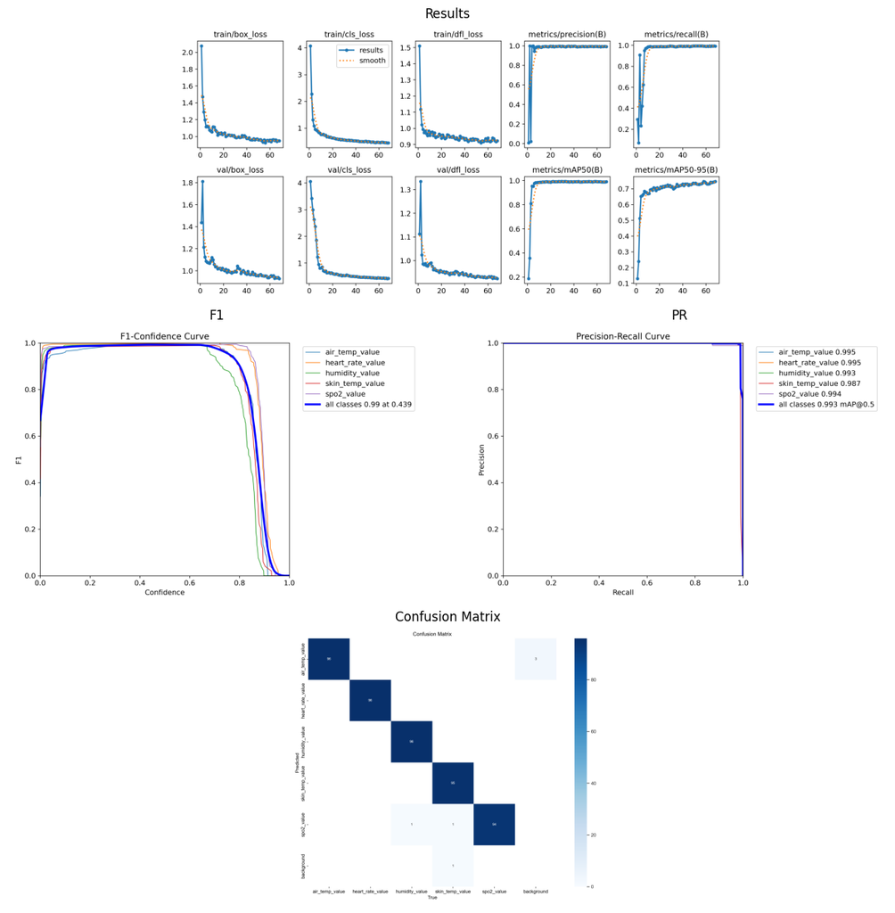

```python
from pathlib import Path
import matplotlib.pyplot as plt

# Set run tag
run_tag = "run_20251203_134740"
eval_dir = Path("../artifacts/runs") / run_tag / "eval_plots"

def first_existing(paths):
    for p in paths:
        if p.exists():
            return p
    return None

results_img = eval_dir / "results.png"
f1_img = first_existing([eval_dir / "f1_curve.png"])
pr_img = first_existing([eval_dir / "pr_curve.png"])
cm_img = first_existing([eval_dir / "confusion_matrix.png"])

fig = plt.figure(figsize=(12, 12), constrained_layout=True)
gs = fig.add_gridspec(3, 2)

# Row 1: results (span 2 columns)
if results_img and results_img.exists():
    ax = fig.add_subplot(gs[0, :])
    ax.imshow(plt.imread(results_img))
    ax.set_title(f"Results")
    ax.axis("off")

# Row 2: F1 and PR side by side
if f1_img and f1_img.exists():
    ax = fig.add_subplot(gs[1, 0])
    ax.imshow(plt.imread(f1_img))
    ax.set_title(f"F1")
    ax.axis("off")

if pr_img and pr_img.exists():
    ax = fig.add_subplot(gs[1, 1])
    ax.imshow(plt.imread(pr_img))
    ax.set_title(f"PR")
    ax.axis("off")

# Row 3: confusion matrix (span 2 columns)
if cm_img and cm_img.exists():
    ax = fig.add_subplot(gs[2, :])
    ax.imshow(plt.imread(cm_img))
    ax.set_title(f"Confusion Matrix")
    ax.axis("off")

plt.show()
```

## 8: Qualitative Predictions

Sample a few images, display predictions, and save rendered outputs to the run folder.

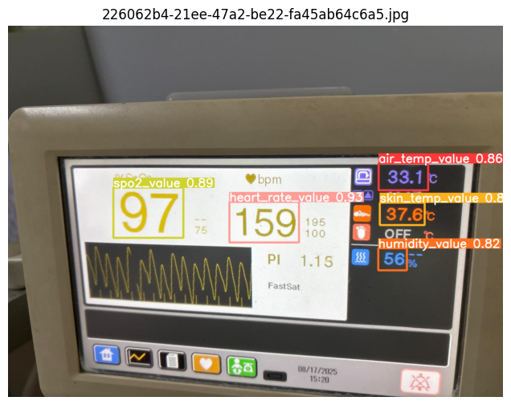

```
Saved c:\Users\sahan\Desktop\MYProjects\PI_webUI_for_test-monitoring\lcd_ocr_readings\artifacts\runs\run_20251203_134740\preds\pred_226062b4-21ee-47a2-be22-fa45ab64c6a5.png
```

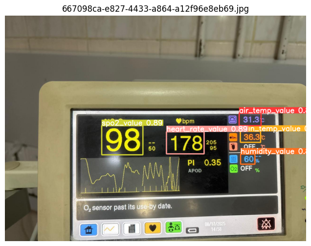

```
Saved c:\Users\sahan\Desktop\MYProjects\PI_webUI_for_test-monitoring\lcd_ocr_readings\artifacts\runs\run_20251203_134740\preds\pred_667098ca-e827-4433-a864-a12f96e8eb69.png
```

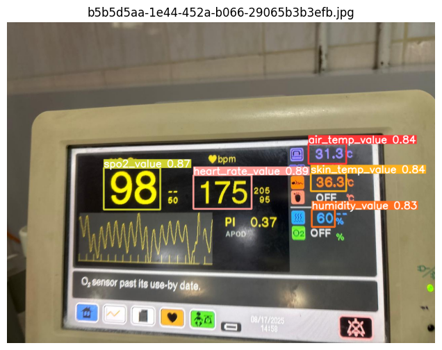

```
Saved c:\Users\sahan\Desktop\MYProjects\PI_webUI_for_test-monitoring\lcd_ocr_readings\artifacts\runs\run_20251203_134740\preds\pred_b5b5d5aa-1e44-452a-b066-29065b3b3efb.png
```

```python
import matplotlib.pyplot as plt

PRED_DIR = RUN_ROOT / "preds"
PRED_DIR.mkdir(parents=True, exist_ok=True)

def visualize_predictions(model, image_paths, class_names, conf=0.25, max_images=3, save_dir=PRED_DIR):
    if not image_paths:
        print("No raw images available for visualization.")
        return
    subset = random.sample(image_paths, min(len(image_paths), max_images))
    for path in subset:
        res = model.predict(source=str(path), conf=conf, verbose=False)
        img_bgr = res[0].plot()
        out_path = save_dir / f"pred_{path.stem}.png"
        cv2.imwrite(str(out_path), img_bgr)
        # Show inline (convert BGR -> RGB for correct colors)
        img_rgb = cv2.cvtColor(img_bgr, cv2.COLOR_BGR2RGB)
        plt.figure(figsize=(8, 6))
        plt.imshow(img_rgb)
        plt.title(path.name)
        plt.axis("off")
        plt.show()
        print(f"Saved {out_path}")

visualize_predictions(detector, image_paths, CLASS_NAMES, max_images=3)
```

## 9: Export Best Weights

Copies the best checkpoint into this run folder and also into `models/` (without overwriting prior runs).

```python
BEST_TARGET = RUN_ROOT / "incubator_yolov8n.pt"

def export_best_weights(run_dir=None, target_path=BEST_TARGET, source_path=None):
    def collect(candidate):
        paths = []
        if candidate is None: return paths
        candidate = Path(candidate)
        if candidate.is_file(): paths.append(candidate)
        elif candidate.is_dir():
            default_best = candidate/"weights"/"best.pt"
            if default_best.exists(): paths.append(default_best)
            paths.extend(candidate.glob("**/best.pt"))
        return paths
    seen, ordered = set(), []
    for item in collect(source_path) + collect(run_dir):
        if item.exists() and item not in seen:
            seen.add(item); ordered.append(item)
    if not ordered:
        print("No best.pt found"); return None
    chosen = ordered[0]
    target_path.parent.mkdir(parents=True, exist_ok=True)
    if not target_path.exists() or target_path.resolve() != chosen.resolve():
        shutil.copy2(chosen, target_path)
        print(f"Exported {chosen} -> {target_path}")
    else:
        print(f"Weights already at {target_path}")
    # also place a copy in models/ with run tag
    models_copy = MODEL_DIR / f"incubator_{RUN_TAG}.pt"
    shutil.copy2(target_path, models_copy)
    print(f"Copied to {models_copy}")
    return target_path

export_best_weights(run_dir=RUN_ROOT / "train")
```

```
Exported c:\Users\sahan\Desktop\MYProjects\PI_webUI_for_test-monitoring\lcd_ocr_readings\artifacts\runs\run_20251203_134740\train\exp\weights\best.pt -> c:\Users\sahan\Desktop\MYProjects\PI_webUI_for_test-monitoring\lcd_ocr_readings\artifacts\runs\run_20251203_134740\incubator_yolov8n.pt
Copied to c:\Users\sahan\Desktop\MYProjects\PI_webUI_for_test-monitoring\lcd_ocr_readings\models\incubator_run_20251203_134740.pt
```

```
WindowsPath('c:/Users/sahan/Desktop/MYProjects/PI_webUI_for_test-monitoring/lcd_ocr_readings/artifacts/runs/run_20251203_134740/incubator_yolov8n.pt')
```

## 10: Save Config Snapshot

Record run configuration for reproducibility.

```python
run_config = {
    "seed": SEED,
    "data_yaml": str(data_yaml_path),
    "class_names": CLASS_NAMES,
    "model": "yolov8n.pt",
    "epochs_max": 100,
    "patience": 10,
    "run_root": str(RUN_ROOT),
    "run_tag": RUN_TAG,
}
config_path = RUN_ROOT / "run_config.json"
config_path.write_text(json.dumps(run_config, indent=2))
print(f"Saved config -> {config_path}")
run_config
```

```
Saved config -> c:\Users\sahan\Desktop\MYProjects\PI_webUI_for_test-monitoring\lcd_ocr_readings\artifacts\runs\run_20251203_134740\run_config.json
```

```
{'seed': 42,
 'data_yaml': 'c:\\Users\\sahan\\Desktop\\MYProjects\\PI_webUI_for_test-monitoring\\lcd_ocr_readings\\artifacts\\runs\\run_20251203_134740\\splits\\data.yaml',
 'class_names': ['air_temp_value',
  'heart_rate_value',
  'humidity_value',
  'skin_temp_value',
  'spo2_value'],
 'model': 'yolov8n.pt',
 'epochs_max': 100,
 'patience': 10,
 'run_root': 'c:\\Users\\sahan\\Desktop\\MYProjects\\PI_webUI_for_test-monitoring\\lcd_ocr_readings\\artifacts\\runs\\run_20251203_134740',
 'run_tag': 'run_20251203_134740'}
```

## 11: OCR (EasyOCR) Setup and OCR on Detections

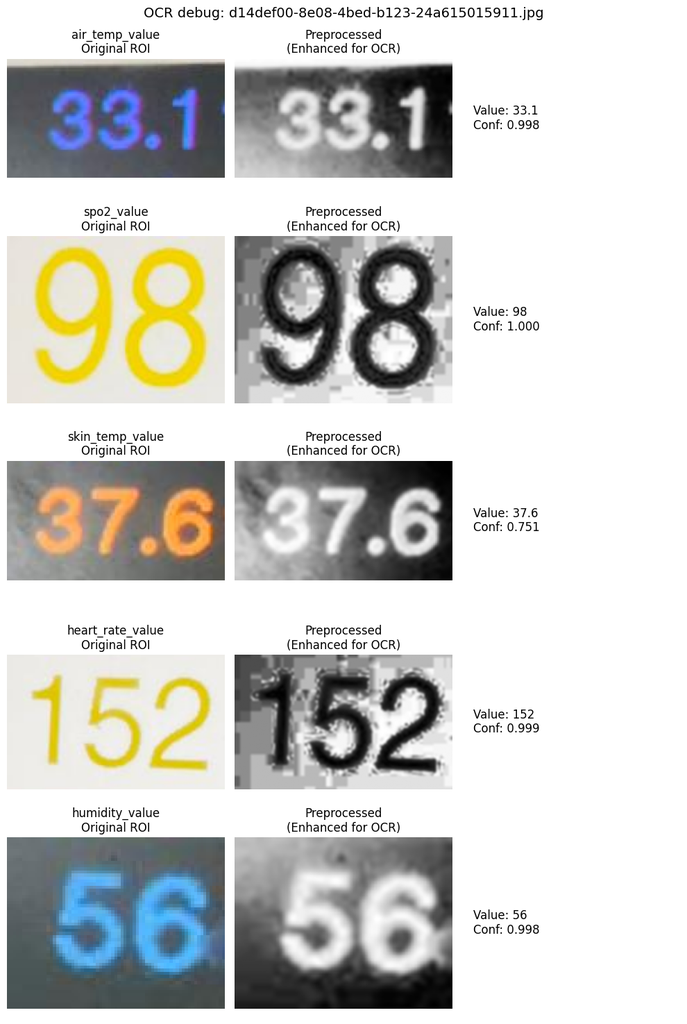

```
Saved grid -> c:\Users\sahan\Desktop\MYProjects\PI_webUI_for_test-monitoring\lcd_ocr_readings\artifacts\runs\run_20251203_134740\ocr_debug.png
```

```python
import matplotlib.pyplot as plt

def visualize_ocr_grid(image_paths, detector, max_rows=6, conf=0.25, save_path=None):
    if not image_paths:
        print("No images available."); return
    img_path = random.choice(image_paths)
    res = detector.predict(source=str(img_path), conf=conf, verbose=False)[0]
    if res.boxes is None or len(res.boxes) == 0:
        print(f"No detections in {img_path.name}"); return

    rows_data = []
    for box_data in res.boxes:
        cls_id = int(box_data.cls[0].cpu().item())
        name = ID_TO_CLASS_NAME.get(cls_id, f"class_{cls_id}")
        if name not in NUMERIC_CLASSES:
            continue
        bbox = box_data.xyxy[0].cpu().numpy().astype(int)
        img = cv2.imread(str(img_path))
        x1, y1, x2, y2 = bbox
        roi = img[y1:y2, x1:x2]
        processed = preprocess_roi(roi) if roi is not None and roi.size > 0 else None
        text, conf_ocr = extract_value(roi)
        rows_data.append((name, roi, processed, text, conf_ocr, y1))

    if not rows_data:
        print(f"No numeric detections in {img_path.name}"); return

    # Sort top-to-bottom
    rows_data = sorted(rows_data, key=lambda r: r[5])[:max_rows]

    n = len(rows_data)
    fig, axes = plt.subplots(n, 3, figsize=(10, 3*n))
    if n == 1:
        axes = [axes]  # make iterable
    for i, (name, roi, processed, text, conf_ocr, _) in enumerate(rows_data):
        # Original
        axes[i][0].imshow(cv2.cvtColor(roi, cv2.COLOR_BGR2RGB))
        axes[i][0].set_title(f"{name}\nOriginal ROI")
        axes[i][0].axis("off")
        # Processed
        axes[i][1].imshow(processed, cmap="gray")
        axes[i][1].set_title("Preprocessed\n(Enhanced for OCR)")
        axes[i][1].axis("off")
        # OCR result
        axes[i][2].axis("off")
        axes[i][2].text(
            0.05, 0.5,
            f"Value: {text if text is not None else 'None'}\nConf: {conf_ocr:.3f}",
            fontsize=12, va="center"
        )

    plt.suptitle(f"OCR debug: {img_path.name}", fontsize=14)
    plt.tight_layout()
    plt.show()

    if save_path:
        fig.savefig(save_path, dpi=150, bbox_inches="tight")
        print(f"Saved grid -> {save_path}")

# Run on a random image and show inline; also save to the run folder
visualize_ocr_grid(image_paths, detector, max_rows=6, conf=0.25, save_path=RUN_ROOT / "ocr_debug.png")
```